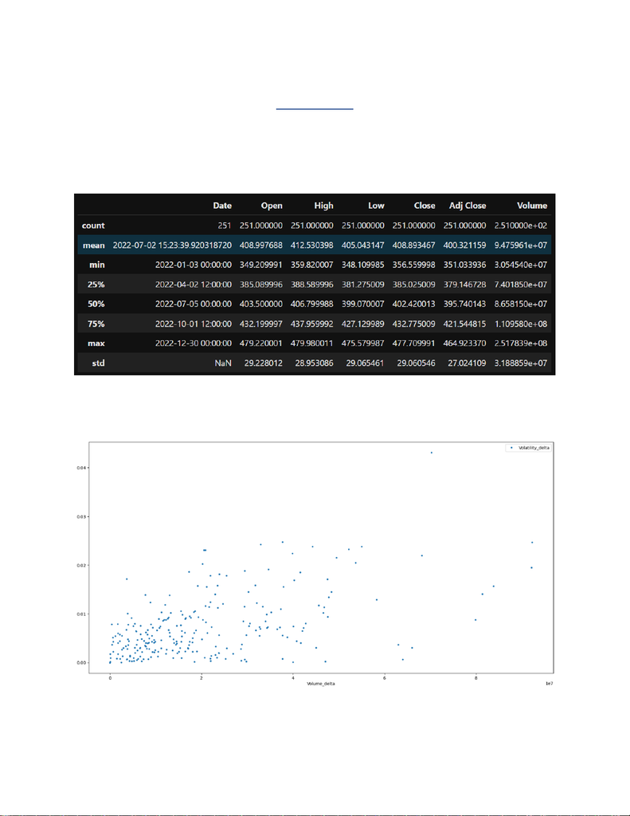

Summary

The historical data of SPDR S&P 500 ETF Trust (SPY) for the year of 2022 was used to develop the

equaon. Inially the data was loaded, the date column was converted from Object class to

DateTime class, and the summary stascs were checked.

As all columns have signicant standard deviaon greater than 0, we can use all the columns for

equaon. Then Intraday Volality which is equal to (High-Low)/Close along with daily volume

change and daily volality change were calculated and ploed.

We can see that, The volality delta value ranges from 0 to 0.05. Before building the equaons,

correlaon plot was ploed to check the inuence of variables.

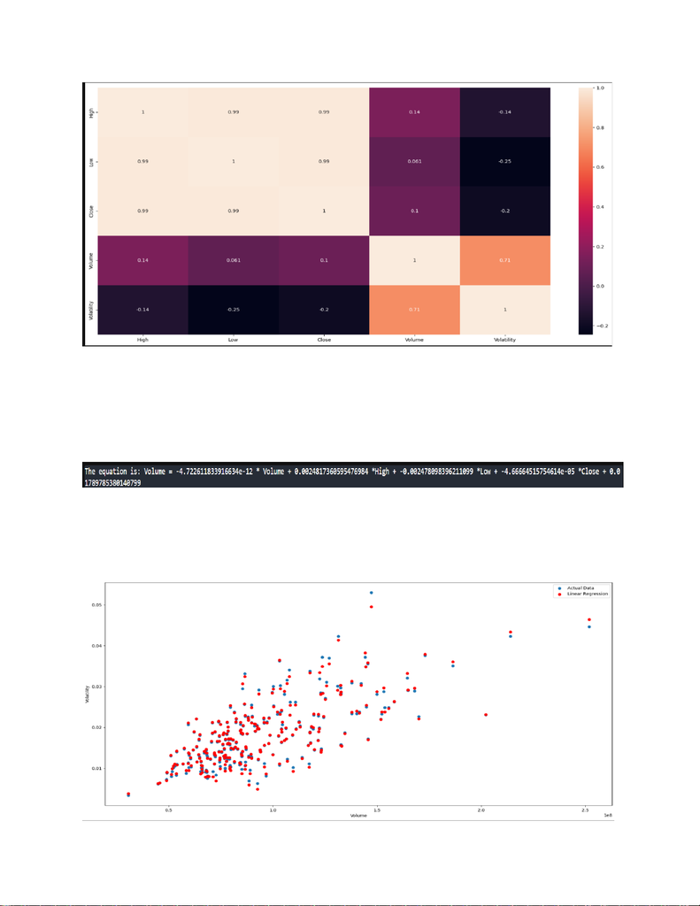

We can see that volume has the highest inuence of 0.71 on volality which means if volume

increases the volality increases. Other variables have mild negave correlaon meaning if

Volality increases the other decreases. Linear Regression was used to build the mul variate

linear equaons using Volume, High, Low and Close.

Case 1: Using Equaon built using SPY on other ETFs and Stocks:

With the above built equaon, the Volality values predicted, and percentage of error was

calculated which is the absolute dierence between predicted and actual value divided by the

actual mes 100. Which gives the change between actual and predicted value. The actual and

predicted value were ploed.

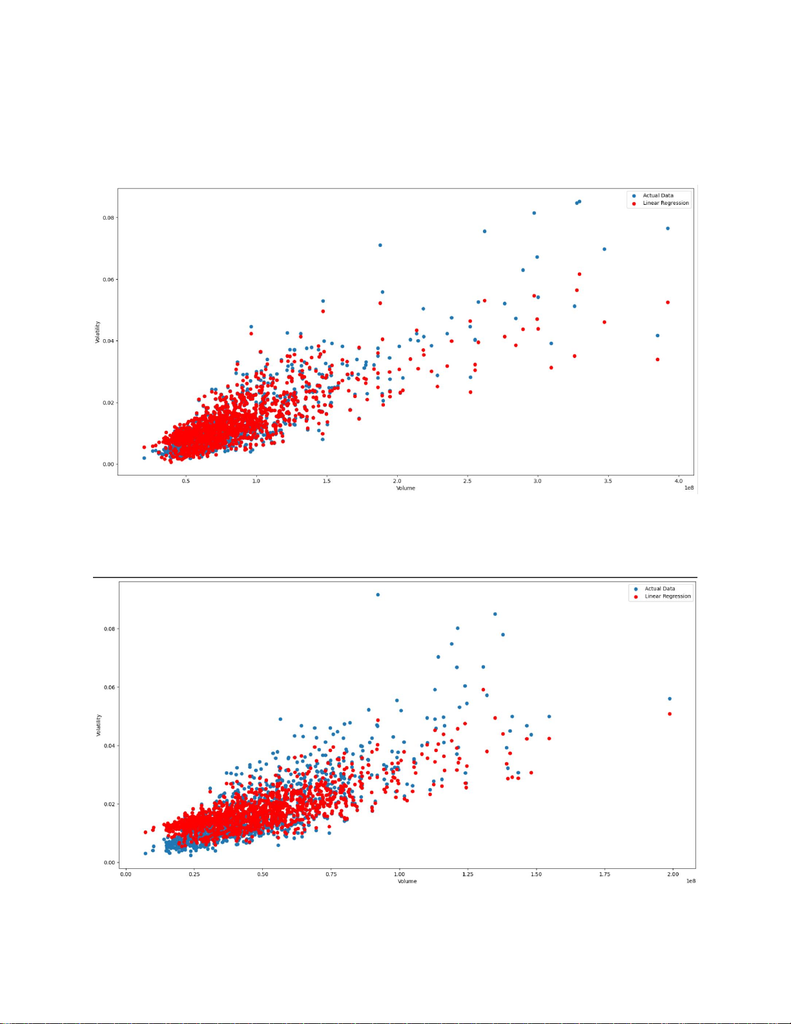

From the plot we can say that the equaons t good for given data. The coecients and intercept

are of small value because the variables ranges are big whereas volality is always less than 1.

This equaon is then used on the same data but for 5 Year interval and its Percentage Error and

scaer plot were calculated and ploed.

The same equaon is ploed for other ETFs QQQ Invesco QQQ Trust Series I and VEA Vanguard

FTSE Developed Markets ETF and Stocks Google and Microso respecvely and the results were

noted down.

QQQ

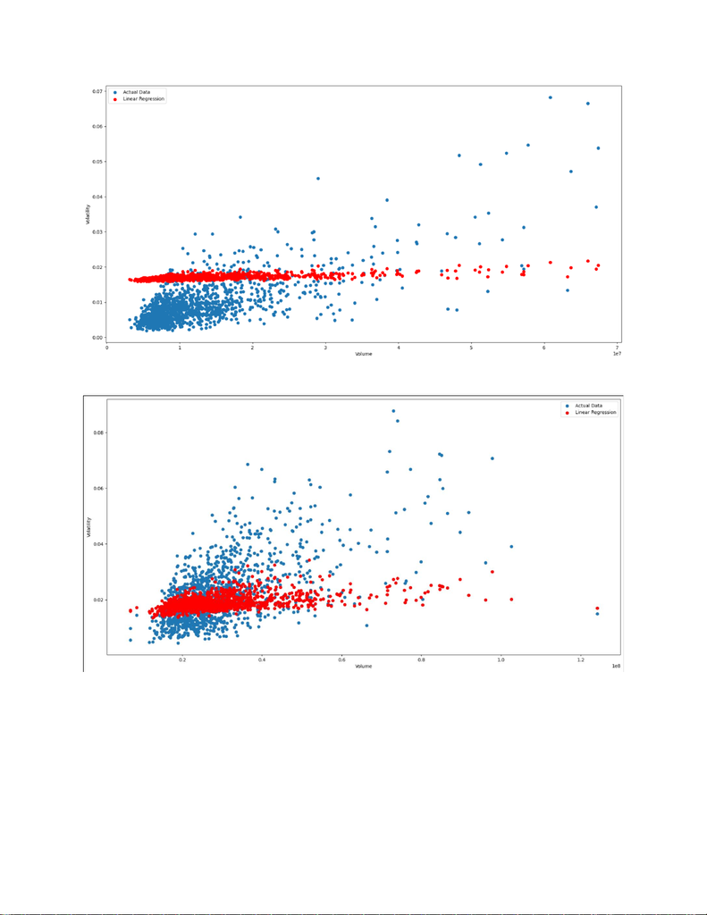

VEA

GOOG

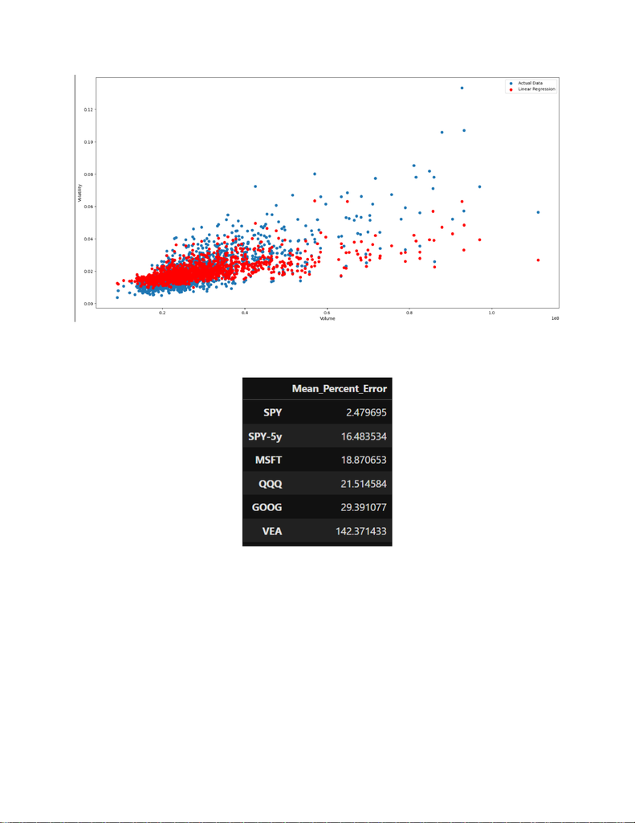

MSFT

Results

We can see the equaon could not represent the actual value well and the mean percentage error

increases with dierent data. This might be since the equaon was largely inuenced by variable

Volume, if it was not as same SPY data then variaons in representaon arises and since the

volality in the dataset with which the equaon was built had values ranging from 0 to 0.06 values

the representaon produced by the equaon is wrong. The mean percentage error is small if the

data has similar values compared to SPY data. Another Shortcoming of this equaon is using

dependent variables such as High, Low, Close which had high dependencies within them.

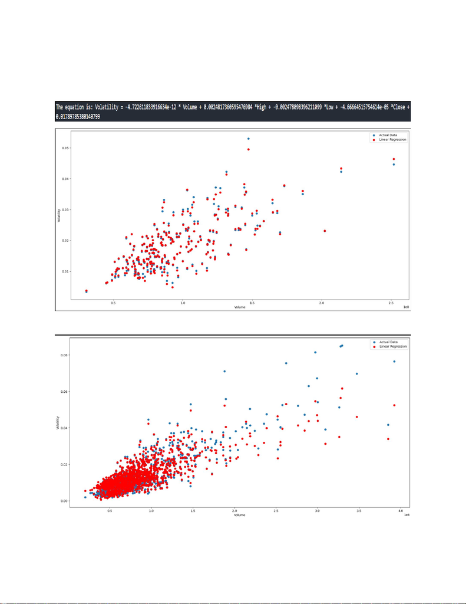

Case 2: Building Equaon for each data and Tesng for 5-year data:

With SPY data using linear regression the equaon was built and tested with its 5-year data.

SPY

SPY-5Y

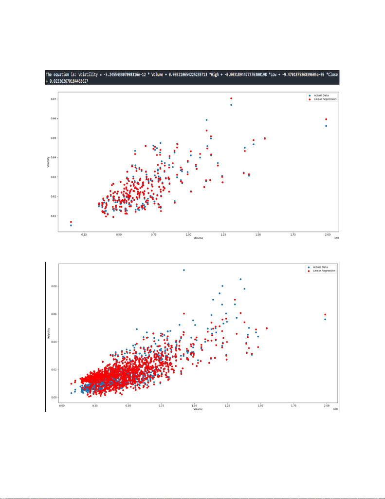

Similarly, 4 equaons for each ETF and Stock were built and the values were ploed.

QQQ:

QQQ

QQQ-5Y

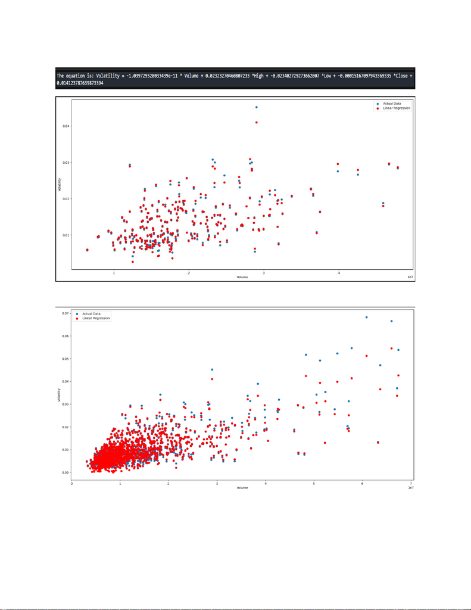

VEA:

VEA

VEA-5Y

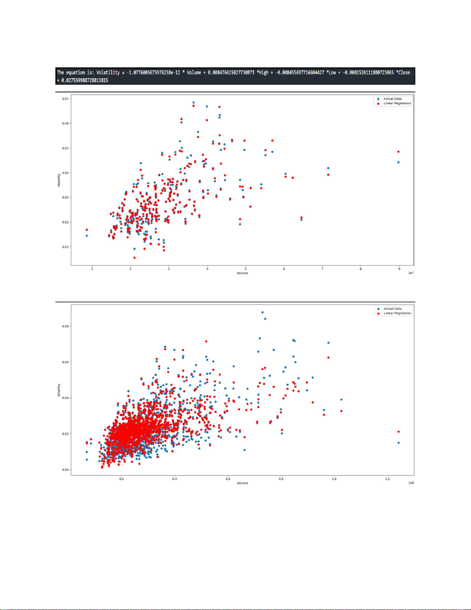

Google:

GOOG

GOOG-5Y

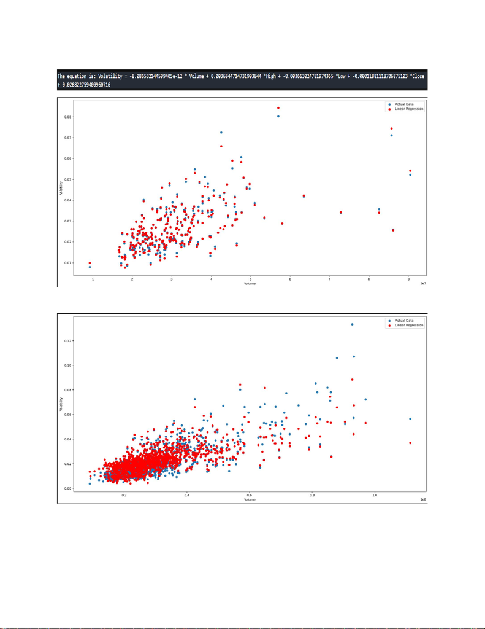

Microso:

MSFT

MSFT-5Y

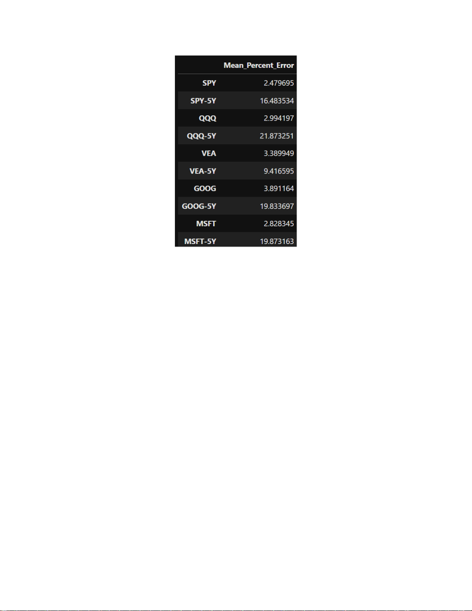

Results

From the above results, the equaons perform well with less mean percentage error and with 5Y

data they have error because of the variaon in Variables that was taken into consideraon, and

they cannot represent volality values more than 0.08. As menoned in the previous case the

equaon has dependent variables which also contribute to the error.